# 0414

##### 算法题

1. 有n个数，每个数出现三次，其中有一个只出现两次，如何用O(1)空间找出这个数？如果是随机删掉两个数（删掉的两个数可能相同也可能不同），找出被删掉的两个数？请写出代码。

```python
# 找到只出现两次的数
import random

def selection_sort(lst): #选择排序，空间复杂度为O(1)
    for i in range(len(lst)-1):
        min_idx = i
        for j in range(i+1, len(lst)):
            if lst[min_idx] > lst[j]:
                min_idx = j
        lst[i], lst[min_idx] = lst[min_idx], lst[i]
    return lst

def twiceNumber(lst):
    nums=selection_sort(lst)
    i = 0
    while i +2 < len(nums):
        if nums[i] == nums[i+2]:
            i += 3
        else:
            return nums[i]
    return nums[-1]

nums=[1,2,1,1,2,3,3,3]
print(twiceNumber(nums))
nums2=[1,1,1,2,2,3,3,3]
print(twiceNumber(nums2))
nums3=[1,2,1,1,2,3,2,3,3,5,5]
print(twiceNumber(nums3))
```

```
2
2
5
```

```python
# 找到删除的两个数
def findDel(copy_nums,nums):
    ori_nums=selection_sort(copy_nums) #删除前的数组排序
    new_nums=selection_sort(nums) #删除后的数组排序

    lst_find=[]
    i,j=0,0
    while i<len(ori_nums):
        if j>=len(ori_nums)-2: #new_nums越界
            lst_find.append(ori_nums[i])
        elif ori_nums[i]!=new_nums[j]:
            lst_find.append(ori_nums[i])
            j-=1
        i+=1
        j+=1
    return lst_find

nums=[1,2,1,1,2,3,3,3]
# 随机删除两个
copy_nums=list.copy(nums)
lst_del=random.sample(nums, 2)
for x in lst_del:
    nums.remove(x)

findDel(copy_nums,nums)
```

```
[1, 2]
```

1. 如何判断平面上两条线段是否相交？给定每条线段的两个端点的坐标。请写出代码。

```python
import numpy as np

def intersect(lst_points):
    # 由点斜式得出一般式(y2-y1)x+(x1-x2)y=x1y2-x2y1
    A=[] #系数矩阵
    B=[] #常数项矩阵
    for points in lst_points:
        x1,x2,y1,y2=points[0][0],points[1][0],points[0][1],points[1][1]
        a1=y2-y1
        a2=x1-x2
        b=x1*y2-x2*y1
        A.append([a1,a2])
        B.append(b)
    x,y = np.linalg.solve(A,B) #求解方程组，得直线交点
    # 在每条线段的两个点中间
    count=0 #交点的x是否在线段端点的x范围内，满足一条则为1
    for points in lst_points:
        x1,x2,y1,y2=points[0][0],points[1][0],points[0][1],points[1][1]
        if min(x1,x2)<=x and x<=max(x1,x2):
            count+=1
    if count==2:
        print('有交点')
    else:
        print('没交点')

# 不相交
lst_points1=[
    [[1,1],[2,2]],
    [[0,3],[1,2]]
]
# 相交于中间
lst_points2=[
    [[0,4],[2,0]],
    [[0,2],[4,0]]
]
# 相交于端点
lst_points3=[
    [[0,2],[1,3]],
    [[0,2],[1,1]]
]

intersect(lst_points1)
intersect(lst_points2)
intersect(lst_points3)
```

```
没交点
有交点
有交点
```

1. 如何判断平面上两个多边形是否有重叠区域？多边形以逆时针方向的坐标序列给出，如(x0, y0), (x1, y1), …, (xn, yn)。 请文字描述算法。

答：如果两个多边形重叠，则至少有一个交点，因此就变成了第二题求交点的问题。对多边形端点进行遍历，每相邻的两个顶点构成一个线段，判断每一条线段是否与另一个多边形相交。

1. 设计一个128位乘128位整数的算法，假设机器位宽是64位。

答：每一个128位的整数用两个64位的表示，如$X*Y=AB*CD=(A0+0B)*(C0+0D)$，其中X和Y是128位的，ABCD是64位的，0表示64位0。 再化简得$A0 * C0 + A0 * 0D + 0B * C0 + 0B * 0D$。其中第一项大于$2^{64}$，需要再拆分，如200位则用4个64位的存储；第四项可以直接计算；第2项和第3项保留低32位，再逻辑左移32位。

1. 计算下面代码 count 的期望值

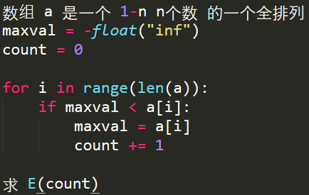

```python
global lst_allrange

def allRange(lst, s=''): #获取全排列
    if len(lst) == 1:
        lst_allrange.append(int(s+str(lst[0])))
        return
    for i,x in enumerate(lst):
        allRange(lst[:i] + lst[i+1:], s+str(x))

def getexp(n): #计算期望
    lst_count=[]
    for lst in lst_allrange:
        a=[int(x) for x in str(lst)]

        maxval=-float("inf")
        count=0

        for i in range(len(a)):
            if maxval<a[i]:
                maxval=a[i]
                count+=1
        lst_count.append(count)
    return sum(lst_count)/len(lst_count)


for n in range(3,10):
    lst_allrange=[] # 用于递归传参
    allRange(list(range(1,n+1)))
    print(n,':',getexp(n))
```

```
3 : 1.8333333333333333
4 : 2.0833333333333335
5 : 2.283333333333333
6 : 2.45
7 : 2.592857142857143
8 : 2.717857142857143
9 : 2.828968253968254
```

综上，找规律可得，期望为$1+\frac{1}{2}+\frac{1}{3}+\frac{1}{4}+...+\frac{1}{n}$，调和数列

##### 基础题

1. 选择ReLU激活函数，有一定概率会屏蔽部分张量的值，这部分值在计算梯度时出直接丢弃，在反向传播时会影响模型的参数修正吗？在多次迭代训练中，是否一定存在模型参数无法被修正的情况?

答：

- 在x<0时，ReLU的值为0。当出现异常输入x时，损失函数会变得很大，因此在反向传播中可能会有很大的梯度g，就可能会使得b变成一个很小的负数。而当输入为正常值时，ReLU的输入很可能是负数，这样会导致该神经元的参数一直不更新。
- 不一定。神经元死亡后是可以复活的，因为其他的神经元参数的更新会导致下一次的输入发生变化。
1. Conv(in_channels=32, out_channels=16, kernel_size=3, stride=2, padding=1, bias=True)，计算可学习的参数个数

答：$$out\_channels*(in\_channels*kernel\_size^2+1)=16*(32*9+1)=4624$$

##### AI设计题

1. 设计一个模型，对文章进行分类，输入是文章的文本（字符串），输出是分类的ID，请写出模型代码和loss的设计。文章长度在1万字以内。可以用Tensorflow或PyTorch。（提示：由于文章篇幅比较长，需考虑序列长度所造成的记忆消失或显存不足等问题）

```python
# Text => CNN => Fully_Connected => Softmax
class CNN:
    def __init__(self, filter_sizes, num_filters, embedded_size,
                 dict_size, maxlen, label_num, learning_rate):

        self.droput_rate = 0.5

        def cnn (input_emb, filter_sizes, num_filters):
            pooled_outputs = []
            for i, filter_size in enumerate(filter_sizes):
                filter_shape = [filter_size, embedded_size, 1, num_filters]
                W = tf.Variable(tf.truncated_normal(filter_shape, stddev=0.1), name="W")
                b = tf.Variable(tf.constant(0.1, shape=[num_filters]), name="b")
                conv = tf.nn.conv2d(
                    input_emb,
                    W,
                    strides=[1, 1, 1, 1],
                    padding="VALID",
                    name="conv")
                h = tf.nn.relu(tf.nn.bias_add(conv, b), name="relu")
                word_num = input_emb.shape.as_list()[1]
                pooled = tf.nn.max_pool(
                    h,
                    ksize=[1, word_num - filter_size + 1, 1, 1],
                    strides=[1, 1, 1, 1],
                    padding='VALID',
                    name="pool")
                pooled_outputs.append(pooled)
            num_filters_total = num_filters * len(filter_sizes)

            h_pool = tf.concat(pooled_outputs,3)

            h_pool_flat = tf.reshape(h_pool, [-1, num_filters_total])

            cnn_fea = tf.nn.dropout(h_pool_flat, keep_prob =  self.droput_rate)

            return cnn_fea

        self.X = tf.placeholder(tf.int32, [None, maxlen], name='input_x')
        self.Y = tf.placeholder(tf.int64, [None])

        self.encoder_embeddings = tf.Variable(tf.random_uniform([dict_size, embedded_size], -1, 1), trainable=False)
        encoder_embedded = tf.nn.embedding_lookup(self.encoder_embeddings, self.X)
        # 由于conv2d需要一个四维的输入数据，因此需要手动添加一个维度。
        encoder_embedded = tf.expand_dims(encoder_embedded, -1) # shape(encoder_embedded) = [None, user_review_num*u_n_words, embedding_size, 1]

        outputs = cnn(input_emb = encoder_embedded, filter_sizes = filter_sizes, num_filters = num_filters)

        self.logits = keras.layers.Dense(label_num, use_bias=True)(outputs)
        self.probability = tf.nn.softmax(self.logits, name='probability')

        self.cost = tf.nn.sparse_softmax_cross_entropy_with_logits(labels = self.Y, logits = self.logits)
        self.cost = tf.reduce_mean(self.cost)
        self.optimizer = tf.train.AdamOptimizer(learning_rate = learning_rate).minimize(self.cost)
        self.pre_y = tf.argmax(self.logits, 1, name='pre_y')
        correct_pred = tf.equal(self.pre_y, self.Y)
        self.accuracy = tf.reduce_mean(tf.cast(correct_pred, tf.float32))
```

1. 设计一个模型，输出一个段落的k个关键词。请用深度学习的方式实现。

```python
from torch import nn

class RNN(nn.Module):
    def __init__(self, input_dim, hidden_dim, layer_dim, output_dim): #layer_dim: RNN的层数
        self.hidden_dim = hidden_dim  ## RNN神经元个数
        self.layer_dim = layer_dim  ## RNN的层数
        self.rnn = nn.RNN(input_dim, hidden_dim, layer_dim,
                          batch_first=True, nonlinearity='relu')
        # 全连阶层
        self.fc1 = nn.Linear(hidden_dim, output_dim)

    def forward(self, x):
        out, h_n = self.rnn(x, None)
        out = self.fc1(out[:, -1, :])
        return out
```